# What is an inverse problem?

[figure not shown]

# Overview

- Applications
- Abstract notions
- The rest of the morning?

# Applications

## X-ray CT

[figure not shown]

## Remote sensing

[figure not shown]

## Geophysical exploration

[figure not shown]

# Abstract notions

## Main ingredients

- The *forward operator* $K$ models the underlying (physical) relations between the *measurements* $f \in \mathcal{F}$ and the image / parameters $u\in\mathcal{U}$.
- The spaces are equiped with a norm $\|\cdot\|$ and in many cases an inner product $\langle \cdot, \cdot\rangle$.
- The inverse problem is for a given $f \in \mathcal{F}$ to find a $u \in \mathcal{U}$ such that $Ku = f$.

## Well-posedness

An inverse problem is *well-posed* if

- A solution exists;
- The solution is unique;
- The solution depends continuously on the data, i.e. for $Ku = f$ and $Kv = g$ there exists a $C < \infty$ such that $$\|u - v\| \leq C \|f - g\|.$$

## Example (root finding)

Given a function $k : \mathbb{R} \rightarrow \mathbb{R}$, and $f \in \mathbb{R}$, find a root $u$ such that $k(u) = f$.

- $k(u) = (u - 1)^2$
- $k(u) = (u - 1)^{3}$
- $k(u) = (u - 1)^{20}$

Is the problem well-posed for $f = -1$? How about for $f = 0$ and $f = 1$?

```python
import numpy as np
import matplotlib.pyplot as plt
```

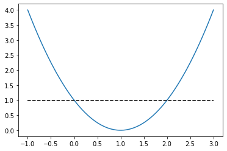

```python
u = np.linspace(-1,3,100)
k = lambda u : (u-1)**2
f = 1

plt.plot(u,k(u),u,0*u+f,'k--')
```

## Example (differentiation)

Given

$$Ku(x) = \int_0^x u(y)\mathrm{d}y,$$

For a given $f$ we find $u(x) = f'(x)$, does this mean the problem is well-posed?

```python
import numpy as np
import matplotlib.pyplot as plt

def plot_example():
    fig, ax = plt.subplots(1,2)

    ax[0].plot(x,f(x))
    ax[0].set_title(r'$f$')
    ax[0].set_xlabel(r'$x$')
    ax[1].plot(x,u(x))
    ax[1].set_title(r'$u$')
    ax[1].set_xlabel(r'$x$')
    fig.tight_layout()
```

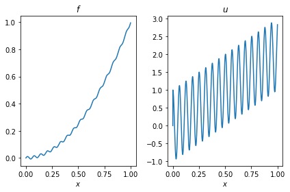

```python
x = np.linspace(0,1,1000)
delta = 1e-2

f = lambda x : x**2 + delta*np.sin(x/delta)
u = lambda x : np.diff(f(x),prepend=0)/(x[1]-x[0])

plot_example()
```

# Program for the rest of the morning

- Detailed analysis of finite-dimensional linear inverse problems
- A Bayesian viewpoint
- Beyond explicit matrix-represenations

Throughout, we will frequently work on examples in Python and learn about some (hopefully) usefull tools.

- Go to https://colab.research.google.com/
- Browse for `TristanvanLeeuwen/Masterclass_IP` to import the notebooks